# FCF Clasicos - A data driven answer

Juan C. Sanchez-Arias

14/10/2021

## Of “El Clasico”, “Derby”, and other tales

The FIFA World Cup is approaching, well sort of. The qualifying season has re-started and I have been trying my earnest to stay up-to-date to what is happening with my gloriosa Seleccion Colombia, after all, it is my home country and the its soil still remembers that wonderful long distance bendy shot from high school (at least I like to think this is the case).

While watching news videos on the subject, I stumbled upon a very interesting discussion from the folks at [F90 at ESPN Fans](https://www.youtube.com/watch?v=bEC7NtQQXi8): Is the Colombia *vs.* Ecuador a “Clasico”? After a heated debate, they anchors couldn’t come up with a clear answer, not even the “data guy” from the show.

Dataset source: [“International football results from 1872 to 2021” (An up-to-date dataset of over 40,000 international football results)](https://www.kaggle.com/martj42/international-football-results-from-1872-to-2017/discussion/208198).

## Wrangling data

```r
# fcf_home <- futbol %>% filter(home_team == "Colombia") %>% group_by(away_team) %>% count(sort = TRUE)
#
# fcf_away <- futbol %>% filter(away_team == "Colombia") %>% group_by(home_team) %>% count(sort = TRUE)

# Coding FCF away/home status per game
fcf_total <- futbol %>% mutate(
  fcf_status = case_when
  (home_team == 'Colombia' ~ 'home',
    away_team == 'Colombia' ~ 'away')) %>%
  na.omit()

# Adding  rival column to ease downstream operations
fcf_total <- fcf_total %>% mutate(
  rival = case_when(
    home_team == 'Colombia' ~ away_team,
    away_team == 'Colombia' ~ home_team
  )
)

# Let's find FCF's Clasicos!
fcf_total %>% group_by(rival) %>% count(sort = TRUE) %>% head(9) %>% knitr::kable()
```

| rival | n |
| --- | --- |
| Peru | 56 |
| Ecuador | 47 |
| Paraguay | 46 |
| Uruguay | 43 |
| Chile | 42 |
| Argentina | 39 |
| Venezuela | 37 |
| Brazil | 32 |
| Bolivia | 30 |

```r
sa <- c("Argentina", "Bolivia", "Brazil", "Ecuador", "Paraguay", "Peru", "Uruguay", "Venezuela")

fcf_total_sa <- fcf_total %>% filter(rival %in% sa)
```

## Let’s plot FCF results against these teams

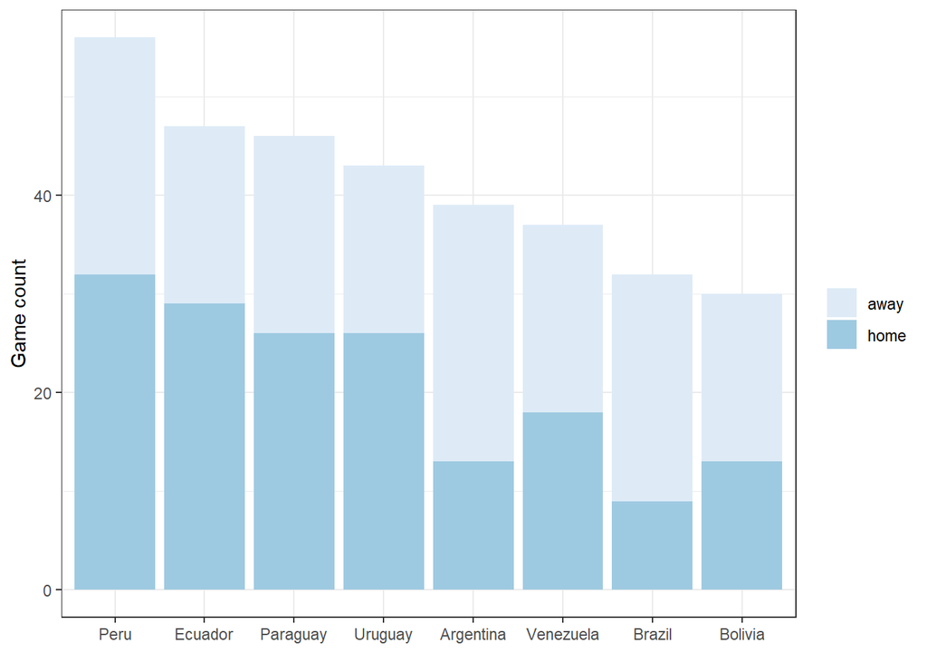

```r
fcf_total_sa %>% group_by(rival, fcf_status) %>% count(sort = TRUE) %>%
  ggplot(aes(x = reorder(rival, desc(n)), y = n, fill = fcf_status)) + geom_col() +
  ylab("Game count") + xlab(element_blank()) +
  scale_fill_brewer(palette = 'Blues') + theme_bw() + theme(legend.title = element_blank())
```

```r
# fcf_total_sa %>% ggplot(aes(x = rival, fill = fcf_status)) + geom_bar() +
#   ylab("Game count") + xlab(element_blank()) +
#   scale_fill_brewer(palette = 'Blues') + theme_bw() + theme(legend.title = element_blank())

fcf_total_sa <- fcf_total_sa %>% mutate(
  goaldiff_fcf = case_when(
    home_team == 'Colombia' ~ home_score - away_score,
    away_team == 'Colombia' ~ away_score - home_score
  )
)
```